# TRABAJO FINAL

Maria Jose Aravena, Alvaro Concha, Francisca Cabrera, Carolina Vejar

2022-12-20

```r
library(tidyverse)
```

```r
library(readxl)
library(skimr)
library(corrplot)
library(broom)
library(lmtest)
library(plm)
datos <- read_excel("EC1116C dataf.xlsx")
base <- read_excel("EC1116C dataf_dicc.xlsx")
```

```r
df <- datos %>%
         select_if(is.numeric)
df[is.na(df)] <- 0
```

Con este codigo se seleccionaron las variables numericas de la base original

```r
a <- base %>%
  filter(CÓDIGO == 'D180')

base[base$`GLOSA PREGUNTA` == "Respecto a su empresa, indique:" ,]
```

```
## # A tibble: 4 × 6
##   `GLOSA PREGUNTA`                CÓDIGO GLOSA               TIPO  RANGO SIGNI…¹
##   <chr>                           <chr>  <chr>               <chr> <chr> <chr>
## 1 Respecto a su empresa, indique: I107   Número  de sindica… NUMÉ… [NÚM… Vacío:…
## 2 Respecto a su empresa, indique: I108   Porcentaje de trab… PORC… Vací… Vacío:…
## 3 Respecto a su empresa, indique: I109   Días no trabajados… NUMÉ… [NÚM… Vacío:…
## 4 Respecto a su empresa, indique: I110   Días no trabajados… NUMÉ… [NÚM… Vacío:…
## # … with abbreviated variable name ¹SIGNIFICADO
```

```r
df1 <- df[,1:25]
df2 <- df[,26:50]
df3 <- df[,51:75]
df4 <- df[,76:100]
df5 <- df[,101:125]
df6 <- df[,126:150]
df7 <- df[,151:175]
df8 <- df[,176:200]
df9 <- df[,201:225]
df10 <- df[,226:250]
df11 <- df[,251:275]
df12 <- df[,276:300]
df13 <- df[,301:325]
df14 <- df[,326:350]
df15 <- df[,351:375]
df16 <- df[,376:400]
df17 <- df[,401:425]
df18 <- df[,425:446]
```

Aca se separo la base de datos en 18 grupos diferentes

```r
df1$GASTOS <- datos$C045
df2$GASTOS <- datos$C045
df3$GASTOS <- datos$C045
df4$GASTOS <- datos$C045
df5$GASTOS <- datos$C045
df6$GASTOS <- datos$C045
df7$GASTOS <- datos$C045
df8$GASTOS <- datos$C045
df9$GASTOS <- datos$C045
df10$GASTOS <- datos$C045
df11$GASTOS <- datos$C045
df12$GASTOS <- datos$C045
df13$GASTOS <- datos$C045
df14$GASTOS <- datos$C045
df15$GASTOS <- datos$C045
df16$GASTOS <- datos$C045
df17$GASTOS <- datos$C045
df18$GASTOS <- datos$C045
```

Y se agrego la variable a explicar en cada uno de los grupos constituidos

```
round(cor(df_n),2)
```

Con este Codigo se fueron explorando las correlaciones de cada uno de los grupos, con respecto a la variable a explicar con el fin de obtener las variables con correlaciones mas fuertes

```r
#Asociaciones gremiales
Gremio <- df$D082

#EXportaciones
Exportaciones <- df$D180

#c041 0.43 Total Ingresos 2019
Ingresos_2019 <- df$C041

#c037 0.43 ingresos por actividad principal 2019
Ingresos_AP2019 <- df$C037

#c006 0.22 costo de venta 2018
Costo_v2018 <- df$C006

#c005 0.42 total ingresos 2018
Ingresos_2018 <- df$C005

#c001 0.41 ingresos por actividad principal 2018
IngresosAP2018 <- df$C001

#c010 0.35 gastos generales 2018
GastosG_2018 <- df$C010

#c012 0.34 remuneraciones 2018
Remun_2018 <- df$C012

#c020 0.42 total gastos 2018
Gastos_2018 <- df$C020

#c022 0.47 activos circulantes 2018
ActivosCir_2018 <- df$C022

#c027 0.48 cuentas por pagar corto plazo 2018
ctasxpagar_2018 <- df$C027

#c046 0.35 gastos generales 2019
GastosG_2019 <- df$C046

#c048 0.38 remuneraciones 2019
Remuner_2019 <- df$C048

#c056 0.43 total gastos 2019
Gastos_2019 <- df$C056

#c058 0.47 activos circulantes 2019
Activoscir_2019 <- df$C058

#c063 0.47 cuentas por pagar corto plazo 2019
ctasxpagar_2019 <- df$C063

#c072 0.35 total pasivos 2019
Pasivos_2019 <- df$C072

#c065 0.35 pasivos circulantes 2019
PasivosCir_2019 <- df$C065

#i161 0.39 REMUNERACIONES DIRECTIVOS Y GERENTES HOMBRES
Remun_directivos_H <- df$I161

#i162 0.35 REMUNERACIONES PROFESIONALES HOMBRES
Remun_prof_H <- df$I162

#i169 0.24 REMUNERACIONES TOTALES HOMBRES
Remun_T_H <- df$I169

#i170 0.45 REMUNERACIONES DIRECTIVOS Y GERENTES MUJERES
Remun_directivos_M <- df$I170

#i171 0.50 REMUNERACIONES Profesionales MUJERES
Remun_prof_M <- df$I171

#i178 0.47 REMUNERACIONES TOTALES MUJERES
Remun_T_M <- df$I178

#i131 0.52 PERSONAS SUBCONTRATADAS MUJERES
Subcontrato_M <- df$I131

#i130 0.45 PERSONAS SUBCONTRATADAS HOMBRES
Subcontrato_H <- df$I130

#Anio inicio
Anio_inicio <- df$A068

#Teletrabajo
Teletrabajo <- df$I114

#Equipos computacionales
Equipos <- df$B092

#Sofrware
Software <- df$B093


Gastos_comunicacion <- df$C045
```

```r
data <- data.frame(Gastos_comunicacion,Ingresos_2019
                   ,Ingresos_2018,
                   Gastos_2018
                   ,Gastos_2019,Activoscir_2019,Pasivos_2019,
                   Remun_directivos_H,Remun_prof_H,Remun_T_H,Remun_directivos_M,Remun_prof_M
                   ,Remun_T_M,Subcontrato_M,Subcontrato_H,Gremio,Anio_inicio,Exportaciones
                   ,Teletrabajo,Equipos,Software)
```

Se crea un data frame con las variables seleccionadas

```r
Gastos_comunicacion_D <- data$Gastos_comunicacion
Gastos_comunicacion_D[Gastos_comunicacion_D > 0] <- 1



data$Gastos_comunicacion_D <- Gastos_comunicacion_D
```

Se crea una nueva variable dicotomica para la decision de gastar o no en comunicacion y TIC

```r
head(data)
```

```
##   Gastos_comunicacion Ingresos_2019 Ingresos_2018 Gastos_2018 Gastos_2019
## 1                   0    7165208000    7613480000  5922114000  6060668000
## 2                1216        236169        228463      208891      219013
## 3                   0     324893544     374117022   361556359   308221546
## 4               33983      61311239      53242433    52076356    58490516
## 5                   0       5867726       5832606     5987799     5980765
## 6                2875        150634        340928      345269      149402
##   Activoscir_2019 Pasivos_2019 Remun_directivos_H Remun_prof_H Remun_T_H
## 1      1299124000  13565221000           15934986     43378259 145517078
## 2          109325       103923              25446            0     52396
## 3        32384333    121946341             752317       445597   1594419
## 4        16420064     33608584             869159       121918   1073074
## 5          472815     10076894              85308       100658    934401
## 6          124014       425477                  0            0     33590
##   Remun_directivos_M Remun_prof_M Remun_T_M Subcontrato_M Subcontrato_H Gremio
## 1            3622111      8704487  21534153          1252          5347      1
## 2                  0            0      8085             0             0      0
## 3             163499       111399    310165             0             0      0
## 4                  0        48444    129866             0             0      0
## 5                  0            0     28779             0             0      0
## 6               9585            0     19901             0             0      0
##   Anio_inicio Exportaciones Teletrabajo Equipos Software Gastos_comunicacion_D
## 1        1985             0           1       0        0                     0
## 2        1973             1           0       0        0                     1
## 3        1993             0           0       1        1                     0
## 4        1988             0           0       1        0                     1
## 5        1991             1           0       0        0                     0
## 6        1991             1           0       0        0                     1
```

## GRAFICO DE CORRELACIONES

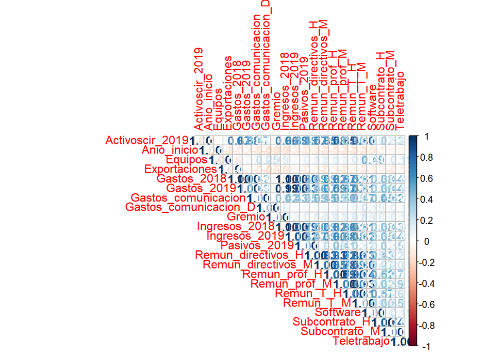

```r
data %>%
  select(where(is.numeric)) %>%
  cor(use = "complete.obs") %>%
  corrplot(method = 'number' , type = 'upper', order = 'alphabet')
```

## TABLA DE CORRELACIONES

```r
round(cor(data),2)
```

```
##                       Gastos_comunicacion Ingresos_2019 Ingresos_2018
## Gastos_comunicacion                  1.00          0.43          0.42
## Ingresos_2019                        0.43          1.00          1.00
## Ingresos_2018                        0.42          1.00          1.00
## Gastos_2018                          0.42          1.00          1.00
## Gastos_2019                          0.43          1.00          0.99
## Activoscir_2019                      0.47          0.69          0.66
## Pasivos_2019                         0.35          0.82          0.79
## Remun_directivos_H                   0.39          0.47          0.50
## Remun_prof_H                         0.35          0.60          0.62
## Remun_T_H                            0.25          0.48          0.51
## Remun_directivos_M                   0.45          0.39          0.39
## Remun_prof_M                         0.50          0.68          0.66
## Remun_T_M                            0.47          0.62          0.61
## Subcontrato_M                        0.52          0.44          0.43
## Subcontrato_H                        0.45          0.35          0.38
## Gremio                               0.09          0.11          0.12
## Anio_inicio                         -0.06         -0.13         -0.13
## Exportaciones                       -0.04         -0.07         -0.08
## Teletrabajo                          0.07          0.09          0.09
## Equipos                              0.07          0.07          0.07
## Software                             0.10          0.10          0.10
## Gastos_comunicacion_D                0.05          0.04          0.04
##                       Gastos_2018 Gastos_2019 Activoscir_2019 Pasivos_2019
## Gastos_comunicacion          0.42        0.43            0.47         0.35
## Ingresos_2019                1.00        1.00            0.69         0.82
## Ingresos_2018                1.00        0.99            0.66         0.79
## Gastos_2018                  1.00        1.00            0.67         0.80
## Gastos_2019                  1.00        1.00            0.68         0.83
## Activoscir_2019              0.67        0.68            1.00         0.49
## Pasivos_2019                 0.80        0.83            0.49         1.00
## Remun_directivos_H           0.49        0.46            0.57         0.13
## Remun_prof_H                 0.62        0.59            0.58         0.26
## Remun_T_H                    0.51        0.47            0.40         0.13
## Remun_directivos_M           0.39        0.37            0.65         0.08
## Remun_prof_M                 0.67        0.67            0.85         0.41
## Remun_T_M                    0.61        0.61            0.80         0.32
## Subcontrato_M                0.44        0.44            0.33         0.35
## Subcontrato_H                0.38        0.36            0.17         0.17
## Gremio                       0.11        0.11            0.10         0.03
```

[output cut: 83 more lines]

```
## Remun_directivos_H           0.12    0.12     0.15                  0.06
## Remun_prof_H                 0.13    0.11     0.14                  0.06
## Remun_T_H                    0.10    0.09     0.12                  0.06
## Remun_directivos_M           0.15    0.11     0.14                  0.05
## Remun_prof_M                 0.13    0.11     0.14                  0.05
## Remun_T_M                    0.15    0.13     0.16                  0.06
## Subcontrato_M                0.03    0.05     0.08                  0.04
## Subcontrato_H                0.02    0.04     0.08                  0.04
## Gremio                       0.13    0.19     0.18                  0.16
## Anio_inicio                 -0.03   -0.10    -0.11                 -0.16
## Exportaciones               -0.13   -0.16    -0.10                 -0.15
## Teletrabajo                  1.00    0.19     0.19                  0.11
## Equipos                      0.19    1.00     0.49                  0.25
## Software                     0.19    0.49     1.00                  0.19
## Gastos_comunicacion_D        0.11    0.25     0.19                  1.00
```

# 1. Explicar la decision de las empresas de gastar o no en servicios de comunicacion y TICs en el a˜no 2019

#### GASTOS COMUNICACION D

##### VARIABLE DICOTOMICA QUE REPRESENTA LA DECICION DE GASTAR EN COMUNICACION Y TIC

##### Variables que tienen una correlacion mas alta con Gastos de comunicacion D

##### **Software 0.19**

##### **Equipos 0.25**

##### **Anio inicio -0.16**

##### **Gremio 0.16**

##### **Exportaciones -0.15**

##### **Teletrabajo 0.11**

### Modelo lineal

```r
mdl1 <- lm(Gastos_comunicacion_D ~ Software + Equipos + Anio_inicio, data = df)
mdl2 <- lm(Gastos_comunicacion_D ~ Software + Equipos + Gremio, data = df)
mdl3 <- lm(Gastos_comunicacion_D ~ Software + Equipos + Exportaciones, data = df)
mdl4 <- lm(Gastos_comunicacion_D ~ Software:Equipos + Anio_inicio, data = df)
mdl5 <- lm(Gastos_comunicacion_D ~ Software:Equipos + Gremio, data = df)
mdl6 <- lm(Gastos_comunicacion_D ~ I(Software*Equipos) + Anio_inicio, data = df)
mdl7 <- lm(Gastos_comunicacion_D ~ I(Software*Equipos) + Gremio, data = df)
```

```r
Modelo1 <- glance(mdl1) %>%
  select(r.squared,df,AIC,BIC) %>%
  mutate(Modelo = "mdl1")

Modelo2 <- glance(mdl2) %>%
  select(r.squared,df,AIC,BIC) %>%
  mutate(Modelo = "mdl2")

Modelo3 <- glance(mdl3) %>%
  select(r.squared,df,AIC,BIC) %>%
  mutate(Modelo = "mdl3")

Modelo4 <- glance(mdl4) %>%
  select(r.squared,df,AIC,BIC) %>%
  mutate(Modelo = "mdl4")

Modelo5 <- glance(mdl5) %>%
  select(r.squared,df,AIC,BIC) %>%
  mutate(Modelo = "mdl5")

Modelo6 <- glance(mdl6) %>%
  select(r.squared,df,AIC,BIC) %>%
  mutate(Modelo = "mdl6")

Modelo7 <- glance(mdl7) %>%
  select(r.squared,df,AIC,BIC) %>%
  mutate(Modelo = "mdl7")
```

```r
bind_rows(Modelo1,Modelo2,Modelo3,Modelo4,Modelo5,Modelo6, Modelo7)
```

```
## # A tibble: 7 × 5
##   r.squared    df   AIC   BIC Modelo
##       <dbl> <dbl> <dbl> <dbl> <chr>
## 1    0.0858     3 5864. 5896. mdl1
## 2    0.0796     3 5894. 5926. mdl2
## 3    0.0798     3 5893. 5926. mdl3
## 4    0.0515     2 6027. 6053. mdl4
## 5    0.0485     2 6041. 6067. mdl5
## 6    0.0515     2 6027. 6053. mdl6
## 7    0.0485     2 6041. 6067. mdl7
```

Se crea una tabla que contiene los valores:

**R^2**, **Grados de libertad**, **AIC**, **BIC**

```r
tidy(mdl1)
```

```
## # A tibble: 4 × 5
##   term        estimate std.error statistic  p.value
##   <chr>          <dbl>     <dbl>     <dbl>    <dbl>
## 1 (Intercept) 11.2      1.15          9.74 3.31e-22
## 2 Software     0.103    0.0220        4.66 3.22e- 6
## 3 Equipos      0.210    0.0173       12.1  2.20e-33
## 4 Anio_inicio -0.00532  0.000573     -9.28 2.57e-20
```

El porcentaje de decision de gasto en comunicacion y tic, aumenta en un 10.3% cuando la empresa tiene unidades de software

El porcentaje de decision de gasto en comunicacion y tic aumenta en 21% cuando la empresa tiene Equipos computacionales

El porcentaje de decision de gasto en comunicacion y tic Disminuye un 0.5% cuando la empresa aumenta 1 anio de funcionamiento

```r
tidy(mdl2)
```

```
## # A tibble: 4 × 5
##   term        estimate std.error statistic  p.value
##   <chr>          <dbl>     <dbl>     <dbl>    <dbl>
## 1 (Intercept)   0.512    0.00875     58.5  0
## 2 Software      0.0994   0.0221       4.49 7.28e- 6
## 3 Equipos       0.203    0.0175      11.6  6.39e-31
## 4 Gremio        0.138    0.0184       7.46 9.99e-14
```

El porcentaje de decision de gasto en comunicacion y tic, aumenta en un 9.9% cuando la empresa tiene unidades de software

El porcentaje de decision de gasto en comunicacion y tic aumenta en 20% cuando la empresa tiene Equipos computacionales

El porcentaje de decision de gasto en comunicacion y tic aumenta un 13.8% cuando la empresa participa de gremios

```r
tidy(mdl3)
```

```
## # A tibble: 4 × 5
##   term          estimate std.error statistic   p.value
##   <chr>            <dbl>     <dbl>     <dbl>     <dbl>
## 1 (Intercept)      0.683    0.0221     30.9  1.01e-190
## 2 Software         0.113    0.0220      5.12 3.15e-  7
## 3 Equipos          0.203    0.0175     11.6  9.79e- 31
## 4 Exportaciones   -0.167    0.0222     -7.51 6.87e- 14
```

El porcentaje de decision de gasto en comunicacion y tic, aumenta en un 11.3% cuando la empresa tiene unidades de software

El porcentaje de decision de gasto en comunicacion y tic aumenta en 20.3% cuando la empresa tiene Equipos computacionales

El porcentaje de decision de gasto en comunicacion y tic disminuye un 16.7% cuando la empresa hace exportaciones

```r
tidy(mdl4)
```

```
## # A tibble: 3 × 5
##   term             estimate std.error statistic  p.value
##   <chr>               <dbl>     <dbl>     <dbl>    <dbl>
## 1 (Intercept)      12.0      1.17         10.3  1.10e-24
## 2 Anio_inicio      -0.00573  0.000583     -9.82 1.57e-22
## 3 Software:Equipos  0.231    0.0213       10.9  3.82e-27
```

CUando hacemos la combinacion $Software:Equipos$, se obtiene una prediccion con distinta pendiente pero el mismo intercepto, esto quiere decir que el punto de partida es el mismo, pero la pendiente cambia entre las variables

y para este modelo se tiene que la decision de gastar en comunicacion y TIC disminuye en un 0.5% cuando el anio de la empresa aumenta

Y para la combinacion de las variables software y equipos se tiene que la decision de gasto aumenta en un 23.1% cuando la empresa tiene unidades de software y equipos computacionales

```r
tidy(mdl5)
```

```
## # A tibble: 3 × 5
##   term             estimate std.error statistic  p.value
##   <chr>               <dbl>     <dbl>     <dbl>    <dbl>
## 1 (Intercept)         0.556   0.00815     68.2  0
## 2 Gremio              0.168   0.0186       9.05 2.17e-19
## 3 Software:Equipos    0.222   0.0215      10.3  1.04e-24
```

Para este caso se utiliza la misma combinacion pero se cambia la variable Anio por la variable Gremio

En este modelo la decision de gasto aumenta con Gremio un 16.8% y con la combinacion de software y equipos aumenta un 22.22%

```r
tidy(mdl6)
```

```
## # A tibble: 3 × 5
##   term                  estimate std.error statistic  p.value
##   <chr>                    <dbl>     <dbl>     <dbl>    <dbl>
## 1 (Intercept)           12.0      1.17         10.3  1.10e-24
## 2 I(Software * Equipos)  0.231    0.0213       10.9  3.82e-27
## 3 Anio_inicio           -0.00573  0.000583     -9.82 1.57e-22
```

Y para este modelo se prensenta que la decision de gastar en comunicacion y TIC aumenta con la combinacion de software y equipos un 23.14% y disminuye un 0.5% a medida que aumentan los anios de la empresa

```r
tidy(mdl7)
```

```
## # A tibble: 3 × 5
##   term                  estimate std.error statistic  p.value
##   <chr>                    <dbl>     <dbl>     <dbl>    <dbl>
## 1 (Intercept)              0.556   0.00815     68.2  0
## 2 I(Software * Equipos)    0.222   0.0215      10.3  1.04e-24
## 3 Gremio                   0.168   0.0186       9.05 2.17e-19
```

Para este modelo se utiliza la misma combinacion $Software*Equipos$ y se tiene que aumenta un 22.22% la decision de gastar en comunicacion y TIC

Y para la variable Gremio la decision de gastar tambien aumenta un 16.8% cuando la empresa pertenece a un Gremio

```
Cabe destacar que cada uno de los modelos y sus respectivas variables presentan un valor-p muy bajo, por lo que se rechaza la hipotesis nula en cada uno de los casos concluyendo asi que todas las variables presentadas en cada uno de los modelos son significativas para la predecir la decision de gasto
```

### MODELOS PROBIT

```r
mdlp1<-glm(Gastos_comunicacion_D ~ Software + Equipos + Anio_inicio, data = data, family = binomial(link = "probit"))

mdlp2<-glm(Gastos_comunicacion_D ~ Software + Equipos + Gremio, data = data, family = binomial(link = "probit"))

mdlp3<-glm(Gastos_comunicacion_D ~ Software + Equipos + Exportaciones, data = data, family = binomial(link = "probit"))

mdlp4<-glm(Gastos_comunicacion_D ~ Software:Equipos + Anio_inicio, data = data, family = binomial(link = "probit"))

mdlp5<-glm(Gastos_comunicacion_D ~ Software:Equipos + Gremio, data = data, family = binomial(link = "probit"))

mdlp6<-glm(Gastos_comunicacion_D ~ I(Software*Equipos) + Anio_inicio, data = data, family = binomial(link = "probit"))

mdlp7<-glm(Gastos_comunicacion_D ~ I(Software*Equipos) + Gremio, data = data, family = binomial(link = "probit"))
```

```r
MP1 <- glance(mdlp1) %>%
  select(AIC,BIC) %>%
  mutate(Modelo = "mdl1")

MP2 <- glance(mdlp2) %>%
  select(AIC,BIC) %>%
  mutate(Modelo = "mdl2")

MP3 <- glance(mdlp3) %>%
  select(AIC,BIC) %>%
  mutate(Modelo = "mdl3")

MP4 <- glance(mdlp4) %>%
  select(AIC,BIC) %>%
  mutate(Modelo = "mdl4")

MP5 <- glance(mdlp5) %>%
  select(AIC,BIC) %>%
  mutate(Modelo = "mdl5")

MP6 <- glance(mdlp6) %>%
  select(AIC,BIC) %>%
  mutate(Modelo = "mdl6")

MP7 <- glance(mdlp7) %>%
  select(AIC,BIC) %>%
  mutate(Modelo = "mdl7")
```

```r
bind_rows(MP1,MP2,MP3,MP4,MP5,MP6,MP7)
```

```
## # A tibble: 7 × 3
##     AIC   BIC Modelo
##   <dbl> <dbl> <chr>
## 1 5550. 5576. mdl1
## 2 5588. 5614. mdl2
## 3 5585. 5611. mdl3
## 4 5711. 5730. mdl4
## 5 5734. 5753. mdl5
## 6 5711. 5730. mdl6
## 7 5734. 5753. mdl7
```

```r
tidy(mdlp1)
```

```
## # A tibble: 4 × 5
##   term        estimate std.error statistic  p.value
##   <chr>          <dbl>     <dbl>     <dbl>    <dbl>
## 1 (Intercept)  35.2      3.73         9.44 3.78e-21
## 2 Software      0.346    0.0677       5.11 3.20e- 7
## 3 Equipos       0.597    0.0503      11.9  1.41e-32
## 4 Anio_inicio  -0.0176   0.00187     -9.42 4.51e-21
```

```r
tidy(mdlp2)
```

```
## # A tibble: 4 × 5
##   term        estimate std.error statistic  p.value
##   <chr>          <dbl>     <dbl>     <dbl>    <dbl>
## 1 (Intercept)   0.0213    0.0237     0.899 3.69e- 1
## 2 Software      0.331     0.0678     4.88  1.06e- 6
## 3 Equipos       0.576     0.0504    11.4   3.14e-30
## 4 Gremio        0.414     0.0550     7.52  5.56e-14
```

```r
tidy(mdlp3)
```

```
## # A tibble: 4 × 5
##   term          estimate std.error statistic  p.value
##   <chr>            <dbl>     <dbl>     <dbl>    <dbl>
## 1 (Intercept)      0.560    0.0683      8.20 2.34e-16
## 2 Software         0.371    0.0676      5.48 4.19e- 8
## 3 Equipos          0.573    0.0505     11.4  6.46e-30
## 4 Exportaciones   -0.527    0.0694     -7.59 3.13e-14
```

```r
tidy(mdlp4)
```

```
## # A tibble: 3 × 5
##   term             estimate std.error statistic  p.value
##   <chr>               <dbl>     <dbl>     <dbl>    <dbl>
## 1 (Intercept)       37.0      3.71         9.97 2.16e-23
## 2 Anio_inicio       -0.0184   0.00185     -9.91 3.74e-23
## 3 Software:Equipos   0.722    0.0666      10.8  2.33e-27
```

```r
tidy(mdlp5)
```

```
## # A tibble: 3 × 5
##   term             estimate std.error statistic  p.value
##   <chr>               <dbl>     <dbl>     <dbl>    <dbl>
## 1 (Intercept)         0.136    0.0217      6.25 4.09e-10
## 2 Gremio              0.488    0.0540      9.04 1.56e-19
## 3 Software:Equipos    0.692    0.0668     10.4  3.51e-25
```

```r
tidy(mdlp6)
```

```
## # A tibble: 3 × 5
##   term                  estimate std.error statistic  p.value
##   <chr>                    <dbl>     <dbl>     <dbl>    <dbl>
## 1 (Intercept)            37.0      3.71         9.97 2.16e-23
## 2 I(Software * Equipos)   0.722    0.0666      10.8  2.33e-27
## 3 Anio_inicio            -0.0184   0.00185     -9.91 3.74e-23
```

```r
tidy(mdlp7)
```

```
## # A tibble: 3 × 5
##   term                  estimate std.error statistic  p.value
##   <chr>                    <dbl>     <dbl>     <dbl>    <dbl>
## 1 (Intercept)              0.136    0.0217      6.25 4.09e-10
## 2 I(Software * Equipos)    0.692    0.0668     10.4  3.51e-25
## 3 Gremio                   0.488    0.0540      9.04 1.56e-19
```

Para resumir, se hicieron 7 modelos probit con las mismas combinaciones hechas en los modelos lineales de lo que se puede concluir que:

Todas las variables presentan una relacion directamente proporcional en relacion a la decision de gasto en comunicacion y TIC, a excepcion de las variables Anio_inicio y Exportaciones que son las unicas dos que presentan una relacion inversa en relacion a la decision de gasto

### MODELOS LOGIT

```r
mdlL1<-glm(Gastos_comunicacion_D ~ Software + Equipos + Anio_inicio, data = data, family = "binomial")

mdlL2<-glm(Gastos_comunicacion_D ~ Software + Equipos + Gremio, data = data, family = "binomial")

mdlL3<-glm(Gastos_comunicacion_D ~ Software + Equipos + Exportaciones, data = data, family = "binomial")

mdlL4<-glm(Gastos_comunicacion_D ~ Software:Equipos + Anio_inicio, data = data, family = "binomial")

mdlL5<-glm(Gastos_comunicacion_D ~ Software:Equipos + Gremio, data = data, family = "binomial")

mdlL6<-glm(Gastos_comunicacion_D ~ I(Software*Equipos) + Anio_inicio, data = data, family = "binomial")

mdlL7<-glm(Gastos_comunicacion_D ~ I(Software*Equipos) + Gremio, data = data, family = "binomial")
```

```r
ML1 <- glance(mdlL1) %>%
  select(AIC,BIC) %>%
  mutate(Modelo = "mdl1")

ML2 <- glance(mdlL2) %>%
  select(AIC,BIC) %>%
  mutate(Modelo = "mdl2")

ML3 <- glance(mdlL3) %>%
  select(AIC,BIC) %>%
  mutate(Modelo = "mdl3")

ML4 <- glance(mdlL4) %>%
  select(AIC,BIC) %>%
  mutate(Modelo = "mdl4")

ML5 <- glance(mdlL5) %>%
  select(AIC,BIC) %>%
  mutate(Modelo = "mdl5")

ML6 <- glance(mdlL6) %>%
  select(AIC,BIC) %>%
  mutate(Modelo = "mdl6")

ML7 <- glance(mdlL7) %>%
  select(AIC,BIC) %>%
  mutate(Modelo = "mdl7")
```

```r
bind_rows(ML1,ML2,ML3,ML4,ML5,ML6,ML7)
```

```
## # A tibble: 7 × 3
##     AIC   BIC Modelo
##   <dbl> <dbl> <chr>
## 1 5548. 5573. mdl1
## 2 5584. 5610. mdl2
## 3 5581. 5607. mdl3
## 4 5709. 5729. mdl4
## 5 5731. 5750. mdl5
## 6 5709. 5729. mdl6
## 7 5731. 5750. mdl7
```

```r
tidy(mdlL1)
```

```
## # A tibble: 4 × 5
##   term        estimate std.error statistic  p.value
##   <chr>          <dbl>     <dbl>     <dbl>    <dbl>
## 1 (Intercept)  58.8      6.32         9.31 1.29e-20
## 2 Software      0.618    0.118        5.23 1.73e- 7
## 3 Equipos       0.986    0.0847      11.6  2.73e-31
## 4 Anio_inicio  -0.0293   0.00316     -9.29 1.50e-20
```

```r
tidy(mdlL2)
```

```
## # A tibble: 4 × 5
##   term        estimate std.error statistic  p.value
##   <chr>          <dbl>     <dbl>     <dbl>    <dbl>
## 1 (Intercept)   0.0264    0.0380     0.693 4.88e- 1
## 2 Software      0.592     0.118      5.00  5.77e- 7
## 3 Equipos       0.952     0.0850    11.2   4.15e-29
## 4 Gremio        0.708     0.0939     7.54  4.64e-14
```

```r
tidy(mdlL3)
```

```
## # A tibble: 4 × 5
##   term          estimate std.error statistic  p.value
##   <chr>            <dbl>     <dbl>     <dbl>    <dbl>
## 1 (Intercept)      0.961    0.119       8.05 8.45e-16
## 2 Software         0.655    0.118       5.54 3.02e- 8
## 3 Equipos          0.949    0.0851     11.2  6.36e-29
## 4 Exportaciones   -0.915    0.122      -7.52 5.31e-14
```

```r
tidy(mdlL4)
```

```
## # A tibble: 3 × 5
##   term             estimate std.error statistic  p.value
##   <chr>               <dbl>     <dbl>     <dbl>    <dbl>
## 1 (Intercept)       61.7      6.26         9.87 5.77e-23
## 2 Anio_inicio       -0.0307   0.00313     -9.82 9.54e-23
## 3 Software:Equipos   1.23     0.119       10.3  5.06e-25
```

```r
tidy(mdlL5)
```

```
## # A tibble: 3 × 5
##   term             estimate std.error statistic  p.value
##   <chr>               <dbl>     <dbl>     <dbl>    <dbl>
## 1 (Intercept)         0.212    0.0348      6.10 1.07e- 9
## 2 Gremio              0.825    0.0920      8.96 3.25e-19
## 3 Software:Equipos    1.19     0.119       9.97 2.12e-23
```

```r
tidy(mdlL6)
```

```
## # A tibble: 3 × 5
##   term                  estimate std.error statistic  p.value
##   <chr>                    <dbl>     <dbl>     <dbl>    <dbl>
## 1 (Intercept)            61.7      6.26         9.87 5.77e-23
## 2 I(Software * Equipos)   1.23     0.119       10.3  5.06e-25
## 3 Anio_inicio            -0.0307   0.00313     -9.82 9.54e-23
```

```r
tidy(mdlL7)
```

```
## # A tibble: 3 × 5
##   term                  estimate std.error statistic  p.value
##   <chr>                    <dbl>     <dbl>     <dbl>    <dbl>
## 1 (Intercept)              0.212    0.0348      6.10 1.07e- 9
## 2 I(Software * Equipos)    1.19     0.119       9.97 2.12e-23
## 3 Gremio                   0.825    0.0920      8.96 3.25e-19
```

Y para resumir, al igual que en los modelos Probit, se tiene que todas las variables presentan una relacion directamente proporcional con la decision de gasto en comunicacion y TIC a excepcion de las variables Anio_inicio y Exportaciones que presentan una relacion inversa con respecto al Gasto

# 2. Explicar el nivel de gastos de servicios de comunicaci´on y TICs de la empresas en el a˜no 2019

Se seleccionan las variables con mas correlacion con respecto al nivel de gasto en comunicacion y TICs

**Ingresos_2019**, **Remun_T_M**, **Remun_T_H**, **Gastos_2019**

### Modelo Lineal

```r
fit1 <- lm(Gastos_comunicacion ~ Ingresos_2019 + Gastos_2019 + Remun_T_H + Remun_T_M, data = df)


fit2 <- lm(Gastos_comunicacion ~ Ingresos_2019:Gastos_2019 + Remun_T_H + Remun_T_M, data = df)

fit3 <- lm(Gastos_comunicacion ~ I(Ingresos_2019*Gastos_2019) + Remun_T_H + Remun_T_M, data = df)

fit4 <- lm(Gastos_comunicacion ~ I(Ingresos_2019*Gastos_2019), data = df)

fit5 <- lm(Gastos_comunicacion ~ Ingresos_2019:Gastos_2019, data = df)

fit6 <- lm(Gastos_comunicacion ~ Ingresos_2019 + Gastos_2019, data = df)
```

```r
Mfit1 <- glance(fit1) %>%
  select(r.squared,df,AIC,BIC) %>%
  mutate(Modelo = "mdl1")

Mfit2 <- glance(fit2) %>%
  select(r.squared,df,AIC,BIC) %>%
  mutate(Modelo = "mdl2")

Mfit3 <- glance(fit3) %>%
  select(r.squared,df,AIC,BIC) %>%
  mutate(Modelo = "mdl3")

Mfit4 <- glance(fit4) %>%
  select(r.squared,df,AIC,BIC) %>%
  mutate(Modelo = "mdl4")

Mfit5 <- glance(fit5) %>%
  select(r.squared,df,AIC,BIC) %>%
  mutate(Modelo = "mdl5")

Mfit6 <- glance(fit6) %>%
  select(r.squared,df,AIC,BIC) %>%
  mutate(Modelo = "mdl6")
```

```r
bind_rows(Mfit1,Mfit2,Mfit3,Mfit4,Mfit5,Mfit6)
```

```
## # A tibble: 6 × 5
##   r.squared    df     AIC     BIC Modelo
##       <dbl> <dbl>   <dbl>   <dbl> <chr>
## 1     0.262     4 146280. 146319. mdl1
## 2     0.263     3 146272. 146304. mdl2
## 3     0.263     3 146272. 146304. mdl3
## 4     0.137     1 146976. 146995. mdl4
## 5     0.137     1 146976. 146995. mdl5
## 6     0.194     2 146672. 146697. mdl6
```

Se puede apreciar que los mejores modelos obtenidos son el modelo 2 y 3 presentando un $R^2$ de 26.3%, ademas de presentar un AIC y BIC menor a los demas modelos

```r
tidy(fit1)
```

```
## # A tibble: 5 × 5
##   term             estimate   std.error statistic  p.value
##   <chr>               <dbl>       <dbl>     <dbl>    <dbl>
## 1 (Intercept)   -2774.      45352.        -0.0612 9.51e- 1
## 2 Ingresos_2019     0.00629     0.00161    3.92   9.06e- 5
## 3 Gastos_2019      -0.00504     0.00163   -3.10   1.94e- 3
## 4 Remun_T_H        -0.0262      0.00398   -6.59   4.80e-11
## 5 Remun_T_M         0.251       0.0124    20.1    1.72e-86
```

Para el modelo 1 se tiene que si los ingresos aumentan en 1 unidad, el nivel de gasto en comunicacion aumenta en 0.00629 unidades

Si los gastos aumentan en 1 unidad, el nivel de gasto en comunicacion disminuye en un -0.00504 unidades

Si las remuneraciones totales para hombres aumentan en 1 unidad los gastos en comunicacion y TICs disminuyen en 0.0262 unidades

Si las remuneraciones totales para mujeres aumentan en 1 unidad los gastos en comunicacion y TICs aumentan en 0.251 unidades

```r
tidy(fit2)
```

```
## # A tibble: 4 × 5
##   term                       estimate std.error statistic   p.value
##   <chr>                         <dbl>     <dbl>     <dbl>     <dbl>
## 1 (Intercept)                1.75e+ 4  4.53e+ 4     0.386 6.99e-  1
## 2 Remun_T_H                 -1.36e- 2  3.92e- 3    -3.48  5.07e-  4
## 3 Remun_T_M                  2.80e- 1  1.16e- 2    24.2   5.24e-122
## 4 Ingresos_2019:Gastos_2019  4.02e-14  2.64e-15    15.2   3.84e- 51
```

Si las remuneraciones totales para hombres aumentan en 1 unidad los gastos en comunicacion y TICs disminuyen en 0.0136 unidades

Si las remuneraciones totales para mujeres aumentan en 1 unidad los gastos en comunicacion y TICs aumentan en 0.28 unidades

```r
tidy(fit3)
```

```
## # A tibble: 4 × 5
##   term                            estimate std.error statistic   p.value
##   <chr>                              <dbl>     <dbl>     <dbl>     <dbl>
## 1 (Intercept)                     1.75e+ 4  4.53e+ 4     0.386 6.99e-  1
## 2 I(Ingresos_2019 * Gastos_2019)  4.02e-14  2.64e-15    15.2   3.84e- 51
## 3 Remun_T_H                      -1.36e- 2  3.92e- 3    -3.48  5.07e-  4
## 4 Remun_T_M                       2.80e- 1  1.16e- 2    24.2   5.24e-122
```

Si las remuneraciones totales para hombres aumentan en 1 unidad los gastos en comunicacion y TICs disminuyen en -1.36e- 2 unidades

Si las remuneraciones totales para mujeres aumentan en 1 unidad los gastos en comunicacion y TICs aumentan en 2.80e- 1 unidades

```r
tidy(fit4)
```

```
## # A tibble: 2 × 5
##   term                           estimate std.error statistic   p.value
##   <chr>                             <dbl>     <dbl>     <dbl>     <dbl>
## 1 (Intercept)                    1.95e+ 5  4.85e+ 4      4.02 5.92e-  5
## 2 I(Ingresos_2019 * Gastos_2019) 6.95e-14  2.61e-15     26.6  6.92e-145
```

Para este modelo se tiene que si la combinacion entre ingresos y gastos del 2019 aumentan en 1 unidad, entonces el gasto en comunicacion y TICs aumenta en 6.95e-14

```r
tidy(fit5)
```

```
## # A tibble: 2 × 5
##   term                      estimate std.error statistic   p.value
##   <chr>                        <dbl>     <dbl>     <dbl>     <dbl>
## 1 (Intercept)               1.95e+ 5  4.85e+ 4      4.02 5.92e-  5
## 2 Ingresos_2019:Gastos_2019 6.95e-14  2.61e-15     26.6  6.92e-145
```

Para este modelo se tiene que si la combinacion entre ingresos y gastos del 2019 aumentan en 1 unidad, entonces el gasto en comunicacion y TICs aumenta en 6.95e-14

```r
tidy(fit6)
```

```
## # A tibble: 3 × 5
##   term            estimate   std.error statistic  p.value
##   <chr>              <dbl>       <dbl>     <dbl>    <dbl>
## 1 (Intercept)   76913.     47058.           1.63 1.02e- 1
## 2 Ingresos_2019     0.0136     0.00162      8.41 5.26e-17
## 3 Gastos_2019      -0.0115     0.00165     -6.97 3.53e-12
```

Para este modelo se tiene que si los ingresos del 2019 aumentan en 1 unidad entonces los gastos de comunicacion y TICs aumentan en 0.0136

Y si los Gastos del 2019 aumentan en 1 unidad entonces el gasto en comunicacion y TICs disminuye en 0.0115 unidades

```
Cabe destacar que para cada uno de los modelos el valor-p de las variables es muy cercano a 0, por lo que se concluye que todas las variables son significativas para la prediccion de la variable Gastos en comunicacion y TICs
```

### Se corrige heterocedasticidad y autocorrelacion

```r
coeftest(fit1,vcov = vcovHC(fit1,type="HC0"))
```

```
##
## t test of coefficients:
##
##                  Estimate  Std. Error t value Pr(>|t|)
## (Intercept)   -2.7740e+03  5.0752e+04 -0.0547 0.956413
## Ingresos_2019  6.2930e-03  7.2980e-03  0.8623 0.388574
## Gastos_2019   -5.0400e-03  7.5539e-03 -0.6672 0.504673
## Remun_T_H     -2.6229e-02  1.0101e-02 -2.5966 0.009446 **
## Remun_T_M      2.5071e-01  1.0771e-01  2.3277 0.019974 *
## ---
## Signif. codes:  0 '***' 0.001 '**' 0.01 '*' 0.05 '.' 0.1 ' ' 1
```

```r
coeftest(fit2,vcov = vcovHC(fit2,type="HC0"))
```

```
##
## t test of coefficients:
##
##                              Estimate  Std. Error t value  Pr(>|t|)
## (Intercept)                1.7513e+04  4.9276e+04  0.3554  0.722301
## Remun_T_H                 -1.3637e-02  1.3326e-02 -1.0234  0.306178
## Remun_T_M                  2.7996e-01  1.0694e-01  2.6179  0.008878 **
## Ingresos_2019:Gastos_2019  4.0160e-14  9.4075e-15  4.2690 2.005e-05 ***
## ---
## Signif. codes:  0 '***' 0.001 '**' 0.01 '*' 0.05 '.' 0.1 ' ' 1
```

Para el modelo 2 las variables significativas son las remuneraciones totales mujeres y la combinacion entre ingresos y gastos 2019

```r
coeftest(fit3,vcov = vcovHC(fit3,type="HC0"))
```

```
##
## t test of coefficients:
##
##                                   Estimate  Std. Error t value  Pr(>|t|)
## (Intercept)                     1.7513e+04  4.9276e+04  0.3554  0.722301
## I(Ingresos_2019 * Gastos_2019)  4.0160e-14  9.4075e-15  4.2690 2.005e-05 ***
## Remun_T_H                      -1.3637e-02  1.3326e-02 -1.0234  0.306178
## Remun_T_M                       2.7996e-01  1.0694e-01  2.6179  0.008878 **
## ---
## Signif. codes:  0 '***' 0.001 '**' 0.01 '*' 0.05 '.' 0.1 ' ' 1
```

Las variables significativas en este caso son las remuneraciones totales mujeres y la combinacion entre ingresos y gastos 2019

```r
coeftest(fit4,vcov = vcovHC(fit4,type="HC0"))
```

```
##
## t test of coefficients:
##
##                                  Estimate Std. Error t value  Pr(>|t|)
## (Intercept)                    1.9476e+05 4.8224e+04  4.0387 5.466e-05 ***
## I(Ingresos_2019 * Gastos_2019) 6.9483e-14 3.5350e-15 19.6554 < 2.2e-16 ***
## ---
## Signif. codes:  0 '***' 0.001 '**' 0.01 '*' 0.05 '.' 0.1 ' ' 1
```

La combinacion entre ingresos y gastos sigue siendo significativa

```r
coeftest(fit5,vcov = vcovHC(fit5,type="HC0"))
```

```
##
## t test of coefficients:
##
##                             Estimate Std. Error t value  Pr(>|t|)
## (Intercept)               1.9476e+05 4.8224e+04  4.0387 5.466e-05 ***
## Ingresos_2019:Gastos_2019 6.9483e-14 3.5350e-15 19.6554 < 2.2e-16 ***
## ---
## Signif. codes:  0 '***' 0.001 '**' 0.01 '*' 0.05 '.' 0.1 ' ' 1
```

En este modelo tambien sigue siendo significativa la relacion entre los ingresos y gastos

```r
coeftest(fit6,vcov = vcovHC(fit6,type="HC0"))
```

```
##
## t test of coefficients:
##
##                  Estimate  Std. Error t value Pr(>|t|)
## (Intercept)    7.6913e+04  3.5437e+04  2.1704  0.03003 *
## Ingresos_2019  1.3601e-02  1.2704e-02  1.0707  0.28437
## Gastos_2019   -1.1510e-02  1.2783e-02 -0.9005  0.36792
## ---
## Signif. codes:  0 '***' 0.001 '**' 0.01 '*' 0.05 '.' 0.1 ' ' 1
```

Los gastos e ingresos del 2019 no son significativos a la hora de predecir

# Conclusiones

## Objetivo 1

Para el objetivo 1, predecir la decision de gastar en servicios de comunicacion y TICs se seleccionaron las variables dicotomicas:

- Software
- Equipos
- Anio inicio
- Gremio
- Exportaciones
- Teletrabajo

Con las cuales se hicieron diferentes modelos lineales, probit y logit para intentar predecir el porcentaje de decision de gasto en comunicacion y TICs

Con esto podemos concluir que si la empresa posee Software y Equipos computacionales entonces aumenta la probabilidad de que esta misma gaste en comunicacion y TICs. Es logico pensar esto ya que los software y equipos computacionales son en si una forma de comunicacion y tecnologia de informacion, por ende se es directamente proporcional al gasto en comunicacion y TICs

## Objetivo 2

Para el objetivo 2, predecir el nivel de gastar en servicios de comunicacion y TICs se seleccionaron las variables:

- Ingresos 2019
- Remuneraciones totales hombres
- Remuneraciones totales mujeres
- Gastos 2019

Se seleccionaron estas variables al comprobar la correlacion entre estas y la variable Gastos en comunicacion y TICs, siendo estas variables las que presentan una correlacion mas fuerte que las demas

Se concluye asi que las variables ingresos y gastos del 2019 por si solas no son significativas, esto se comprueba con la correccion de la matriz HAC, pero al juntarlas y combinarlas si son significativas a la hora de predecir el nivel de gasto en comunicacion y TICs